# Implementing and Optimizing Digital Marketing

Wellness Ranch Therapy Capstone Project

Brian Vuong

IBM 6500, Cal Poly Pomona

2026-10-03

# Implementing and Optimizing Digital Marketing

## Wellness Ranch Therapy Capstone Project

**Central question:** Which website, SEO, analytics, and search advertising improvements will most effectively increase visibility, engagement, and meaningful conversions for Wellness Ranch Therapy?

# Table of Contents

- Introduction and business problem
- Analytics objective
- Consumer behavior concepts
- Data and sampling
- Data wrangling and measures
- Proposed analytics methods
- Demonstration chart
- Implementation plan
- Limitations and next steps
- References and appendix

# Introduction

## Business Problem

Wellness Ranch Therapy needs a sustainable digital-marketing system that can help potential clients:

- Discover the organization online
- Understand the services offered
- Build trust in the organization
- Navigate the website
- Request information or services
- Stay engaged over time

The organization may need stronger connections between:

- Website content
- Search-engine visibility
- Digital advertising
- Social-media communication
- Analytics tracking
- Conversion goals

The goal is to improve digital visibility while encouraging meaningful engagement and measurable conversions.

# Analytics Objective

## Primary Objective

> Evaluate which digital marketing improvements most effectively increase visibility, engagement, and meaningful conversions for Wellness Ranch Therapy.

### Supporting Questions

1. How are potential clients currently discovering Wellness Ranch Therapy?
2. Which website pages receive the greatest amount of attention?
3. Which search terms and channels produce qualified traffic?
4. Which website actions indicate meaningful engagement?
5. Which campaigns generate inquiries or other conversions?
6. How can digital marketing performance be measured consistently?

# Why This Matters

A data-driven digital-marketing system could help Wellness Ranch Therapy:

- Increase awareness among relevant audiences
- Improve search-engine visibility
- Make the website easier to navigate
- Build trust with potential clients
- Increase meaningful inquiries and conversions
- Prioritize limited marketing resources
- Evaluate whether digital improvements are working

# Consumer Behavior Framework

## Digital Customer Journey

Potential clients may move through several stages:

```
Awareness
   ↓
Search and Discovery
   ↓
Website Visit
   ↓
Trust and Evaluation
   ↓
Inquiry or Conversion
   ↓
Continued Engagement
```

Each stage requires different content, communication, and performance measures.

# Relevant Concepts

### Customer Journey

Potential clients may use multiple channels before taking action.

### Search Behavior

Search terms can reveal questions, needs, and intent.

### Trust Formation

Clear information and credible communication can reduce uncertainty.

### Conversion

A conversion may include an inquiry, form submission, call, or appointment request.

### Engagement

Engagement includes meaningful actions rather than page views alone.

### Retention

Continued communication may support long-term relationships.

# Adequacy of Available Information

## Initial Data Assessment

| Information area | Potential use | Expected limitation |
| --- | --- | --- |
| Website analytics | Measure traffic and user behavior | May not explain visitor intent |
| Search Console data | Examine search visibility and queries | Historical data may be limited |
| Website content | Evaluate clarity and relevance | Content quality can be subjective |
| Advertising data | Measure impressions, clicks, and cost | Clicks may not become conversions |
| Social media data | Measure reach and engagement | Engagement does not equal qualified leads |
| Inquiry records | Measure meaningful outcomes | Records may be incomplete |
| Stakeholder interviews | Understand goals and barriers | Responses may reflect personal perceptions |

# Need for Additional Analysis

Additional analysis may be necessary if:

- Website traffic is not connected to conversion actions
- Analytics tracking is incomplete
- Search terms are unavailable
- Conversion definitions are unclear
- Advertising costs are missing
- Inquiry records are stored inconsistently
- Different platforms use different measures
- Website visitors cannot be distinguished from qualified prospects

**Warning**

High traffic, impressions, or social-media engagement does not necessarily mean that the organization is receiving more meaningful inquiries.

# Data and Sampling

## Proposed Data Sources

1. Google Analytics or website analytics
2. Google Search Console
3. Website content and page structure
4. Google Ads or search-advertising reports
5. Social-media performance data
6. Inquiry, contact, or referral records
7. Stakeholder interviews
8. Existing marketing materials
9. Competitor and search-result review

## Unit of Analysis

The analysis may use:

- One website session
- One website visitor
- One page
- One search query
- One advertising campaign
- One conversion
- One week or month
- One audience segment

# Data Wrangling Plan

```
Collect data from digital platforms
   ↓
Standardize dates and channel names
   ↓
Remove duplicate records
   ↓
Identify missing values
   ↓
Define meaningful conversions
   ↓
Combine website, search, advertising, and inquiry data
   ↓
Calculate performance measures
   ↓
Validate the final analysis dataset
```

| Variable | Description | Example |
| --- | --- | --- |
| `date` | Date of activity | 2026-09-12 |
| `channel` | Source of traffic | Organic Search |
| `sessions` | Website visits | 425 |
| `engaged_sessions` | Meaningful visits | 280 |
| `conversions` | Completed desired actions | 18 |
| `marketing_cost` | Advertising cost | 750 |
| `landing_page` | Page visited first | Services |
| `conversion_type` | Type of action | Contact Form |

# Measures

## Key Performance Indicators

### Visibility

- Search impressions
- Search ranking
- Website sessions
- Organic traffic
- Brand searches

### Engagement

- Engaged sessions
- Time on page
- Pages per session
- Service-page visits
- Resource downloads

### Conversion

- Contact-form submissions
- Phone calls
- Appointment requests
- Referral inquiries
- Conversion rate

### Efficiency

- Cost per conversion
- Cost per qualified inquiry
- Return on advertising spend
- Conversion rate by channel

# Reproducible Demonstration Data

The following code creates a simulated dataset for demonstration purposes.

The data should eventually be replaced with validated Wellness Ranch Therapy data.

```r
channel_data <- tibble(
  channel = c(
    "Organic Search",
    "Google Ads",
    "Social Media",
    "Email",
    "Referral Traffic"
  ),
  sessions = c(620, 410, 355, 180, 145),
  conversions = c(32, 27, 12, 14, 18),
  marketing_cost = c(300, 950, 240, 120, 80)
) |>
  mutate(
    conversion_rate = conversions / sessions,
    cost_per_conversion = marketing_cost / conversions
  )

channel_data
```

```
# A tibble: 5 × 6
  channel          sessions conversions marketing_cost conversion_rate
  <chr>               <dbl>       <dbl>          <dbl>           <dbl>
1 Organic Search        620          32            300          0.0516
2 Google Ads            410          27            950          0.0659
3 Social Media          355          12            240          0.0338
4 Email                 180          14            120          0.0778
5 Referral Traffic      145          18             80          0.124
# ℹ 1 more variable: cost_per_conversion <dbl>
```

# Demonstration Chart

## Conversions by Digital Channel

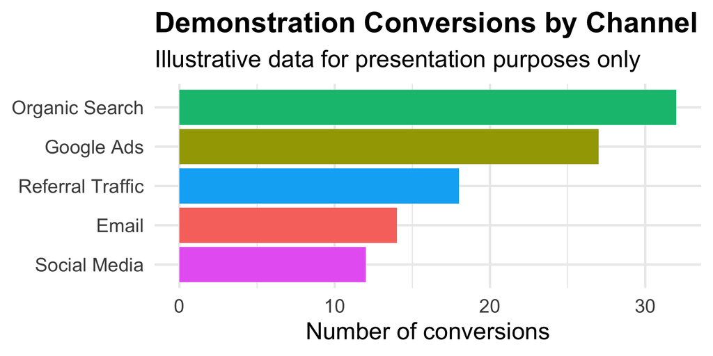

Figure 1: Demonstration number of conversions by digital marketing channel.

# Demonstration Findings

Based on the demonstration data:

- Organic Search generated the largest number of conversions.
- Referral Traffic produced a relatively high number of conversions compared with its traffic volume.
- Google Ads generated conversions but had the highest marketing cost.
- Social-media engagement should be evaluated based on meaningful actions.
- Additional information is needed to determine the quality of each conversion.

The demonstration shows why channel performance should be evaluated using both volume and efficiency.

# Example Summary Table

Table 1: Demonstration summary of digital channel performance.

| Channel | Sessions | Conversions | Marketing Cost | Conversion Rate | Cost per Conversion |
| --- | --- | --- | --- | --- | --- |
| Organic Search | 620 | 32 | $300 | 5.2% | $9.38 |
| Google Ads | 410 | 27 | $950 | 6.6% | $35.19 |
| Social Media | 355 | 12 | $240 | 3.4% | $20.00 |
| Email | 180 | 14 | $120 | 7.8% | $8.57 |
| Referral Traffic | 145 | 18 | $80 | 12.4% | $4.44 |

# Proposed Analytics Methods

## Descriptive Analysis

The first stage will summarize:

- Website traffic by channel
- Search impressions and clicks
- Page-level engagement
- Landing-page performance
- Advertising spend
- Conversion activity
- Inquiry volume over time

## Comparative Analysis

The project may compare:

- Organic versus paid traffic
- New versus returning visitors
- Service pages versus informational pages
- Campaign periods versus non-campaign periods
- Different landing pages
- Different search terms
- Different audience segments

# Proposed Analytics Methods

## Predictive or Explanatory Analysis

Depending on the available data, possible methods include:

- Conversion-rate analysis
- Search-keyword analysis
- Website funnel analysis
- Customer or audience segmentation
- Regression analysis
- A/B testing
- Time-series comparison
- Cost-per-conversion analysis
- Campaign attribution analysis

The final method will depend on the quality, size, and structure of the available data.

# Website and SEO Opportunities

Potential improvement areas include:

### Website

- Clear service descriptions
- Strong calls to action
- Easier navigation
- Mobile-friendly design
- Accessible contact information
- Trust-building content

### SEO

- Relevant search terms
- Improved page titles
- Descriptive headings
- Local search optimization
- Updated metadata
- Helpful educational content

# Digital Advertising Opportunities

Search advertising can be evaluated using:

- Keyword relevance
- Click-through rate
- Landing-page quality
- Conversion rate
- Cost per click
- Cost per conversion
- Qualified inquiry rate
- Search intent

**Note**

Advertising performance should be measured by meaningful outcomes rather than clicks alone.

# Implementation Plan

## Recommended Phases

```
Phase 1: Assessment
   ↓
Phase 2: Tracking and Measurement
   ↓
Phase 3: Website and SEO Improvements
   ↓
Phase 4: Search Advertising Optimization
   ↓
Phase 5: Performance Evaluation
   ↓
Phase 6: Continuous Improvement
```

# Proposed Deliverables

Potential deliverables include:

1. Digital-marketing audit
2. Website and SEO assessment
3. Analytics and conversion-tracking plan
4. Keyword and search-intent analysis
5. Website-content recommendations
6. Search-advertising recommendations
7. Conversion funnel analysis
8. Digital-marketing performance dashboard
9. Campaign-measurement template
10. Implementation and evaluation plan

# Storytelling Framework

```
What are potential clients searching for?
        ↓
How are they finding Wellness Ranch Therapy?
        ↓
What do they do on the website?
        ↓
Where does the digital journey break down?
        ↓
Which improvements should be implemented first?
        ↓
How will success be measured?
```

The final recommendations should be practical, measurable, and aligned with Wellness Ranch Therapy’s mission and available resources.

# Limitations

Important limitations may include:

- Small or incomplete datasets
- Missing historical analytics
- Inconsistent conversion tracking
- Limited advertising data
- Privacy restrictions
- Difficulty measuring offline inquiries
- Small sample sizes
- Limited ability to establish causality
- Changes in search-engine algorithms
- External changes in audience behavior

# Next Steps

1. Confirm Wellness Ranch Therapy’s primary business goals.
2. Identify the most important audience segments.
3. Inventory all current digital platforms and data sources.
4. Define meaningful conversion events.
5. Review website content and technical structure.
6. Establish baseline performance measures.
7. Implement priority website and SEO improvements.
8. Test and evaluate search advertising improvements.
9. Review results with stakeholders.
10. Develop a sustainable measurement process.

# Conclusion

The central project question is:

> Which website, SEO, analytics, and search advertising improvements will most effectively increase visibility, engagement, and meaningful conversions for Wellness Ranch Therapy?

### Current Challenge

- Limited digital measurement
- Unclear conversion paths
- Possible gaps in website content
- Difficulty connecting channels to outcomes

### Desired Outcome

- Greater online visibility
- Better website experience
- More meaningful inquiries
- Improved campaign measurement
- Sustainable digital growth

# References

1. Lemon, K. N., & Verhoef, P. C. (2016). Understanding customer experience throughout the customer journey. *Journal of Marketing, 80*(6), 69–96. [Link](https://doi.org/10.1509/jm.15.0420)
2. Google. (2026). *Google Analytics documentation*. [Link](https://support.google.com/analytics/)
3. Google. (2026). *Search Console documentation*. [Link](https://support.google.com/webmasters/)
4. Google. (2026). *SEO Starter Guide*. [Link](https://developers.google.com/search/docs/fundamentals/seo-starter-guide)
5. Quarto. (2026). *Presentations with Quarto Revealjs*. [Link](https://quarto.org/docs/presentations/revealjs/)

# Appendix

## Appendix Navigation

- Return to the introduction
- View the analytics objective
- View the data and sampling plan
- View the demonstration chart
- View the implementation plan
- View the references

# Appendix: Example R Code

```r
channel_data |>
  arrange(desc(conversions)) |>
  select(
    channel,
    sessions,
    conversions,
    marketing_cost,
    conversion_rate,
    cost_per_conversion
)
```

```
# A tibble: 5 × 6
  channel          sessions conversions marketing_cost conversion_rate
  <chr>               <dbl>       <dbl>          <dbl>           <dbl>
1 Organic Search        620          32            300          0.0516
2 Google Ads            410          27            950          0.0659
3 Referral Traffic      145          18             80          0.124
4 Email                 180          14            120          0.0778
5 Social Media          355          12            240          0.0338
# ℹ 1 more variable: cost_per_conversion <dbl>
```

# Appendix

- [GitHub Repository](https://github.com/brianvuong1/ibm-6500)
- [Published Article Notes on GitHub Pages](https://brianvuong1.github.io/ibm-6500/cep-short-title.html)